# SLV practical 3

Amalia Tsakali

2022-10-03

```r
library(tidyverse)
library(magrittr)
library(mice)
library(DAAG)
```

##the boys dataset

```r
head(boys)
```

```
##      age  hgt   wgt   bmi   hc  gen  phb tv   reg
## 3  0.035 50.1 3.650 14.54 33.7 <NA> <NA> NA south
## 4  0.038 53.5 3.370 11.77 35.0 <NA> <NA> NA south
## 18 0.057 50.0 3.140 12.56 35.2 <NA> <NA> NA south
## 23 0.060 54.5 4.270 14.37 36.7 <NA> <NA> NA south
## 28 0.062 57.5 5.030 15.21 37.3 <NA> <NA> NA south
## 36 0.068 55.5 4.655 15.11 37.0 <NA> <NA> NA south
```

```r
tail(boys)
```

```
##         age   hgt  wgt   bmi   hc  gen  phb tv   reg
## 7410 20.372 188.7 59.8 16.79 55.2 <NA> <NA> NA  west
## 7418 20.429 181.1 67.2 20.48 56.6 <NA> <NA> NA north
## 7444 20.761 189.1 88.0 24.60   NA <NA> <NA> NA  west
## 7447 20.780 193.5 75.4 20.13   NA <NA> <NA> NA  west
## 7451 20.813 189.0 78.0 21.83 59.9 <NA> <NA> NA north
## 7475 21.177 181.8 76.5 23.14   NA <NA> <NA> NA  east
```

```r
!is.unsorted(boys$age)
```

```
## [1] TRUE
```

```r
summary(boys)
```

```
##       age              hgt              wgt              bmi
##  Min.   : 0.035   Min.   : 50.00   Min.   :  3.14   Min.   :11.77
##  1st Qu.: 1.581   1st Qu.: 84.88   1st Qu.: 11.70   1st Qu.:15.90
##  Median :10.505   Median :147.30   Median : 34.65   Median :17.45
##  Mean   : 9.159   Mean   :132.15   Mean   : 37.15   Mean   :18.07
##  3rd Qu.:15.267   3rd Qu.:175.22   3rd Qu.: 59.58   3rd Qu.:19.53
##  Max.   :21.177   Max.   :198.00   Max.   :117.40   Max.   :31.74
##                   NA's   :20       NA's   :4        NA's   :21
##        hc          gen        phb            tv           reg
##  Min.   :33.70   G1  : 56   P1  : 63   Min.   : 1.00   north: 81
##  1st Qu.:48.12   G2  : 50   P2  : 40   1st Qu.: 4.00   east :161
##  Median :53.00   G3  : 22   P3  : 19   Median :12.00   west :239
##  Mean   :51.51   G4  : 42   P4  : 32   Mean   :11.89   south:191
##  3rd Qu.:56.00   G5  : 75   P5  : 50   3rd Qu.:20.00   city : 73
##  Max.   :65.00   NA's:503   P6  : 41   Max.   :25.00   NA's :  3
##  NA's   :46                 NA's:503   NA's   :522
```

1. Create a histogram of the variable age using the function geom_histogram().

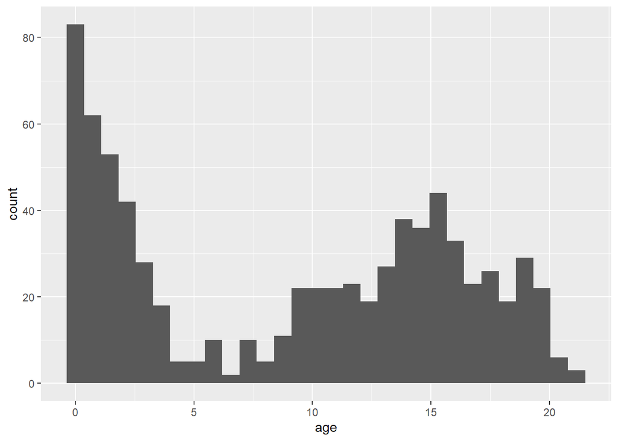

```r
boys %>% ggplot(aes(x=age))+geom_histogram()
```

2. Create a bar chart of the variable gen using the function geom_bar().

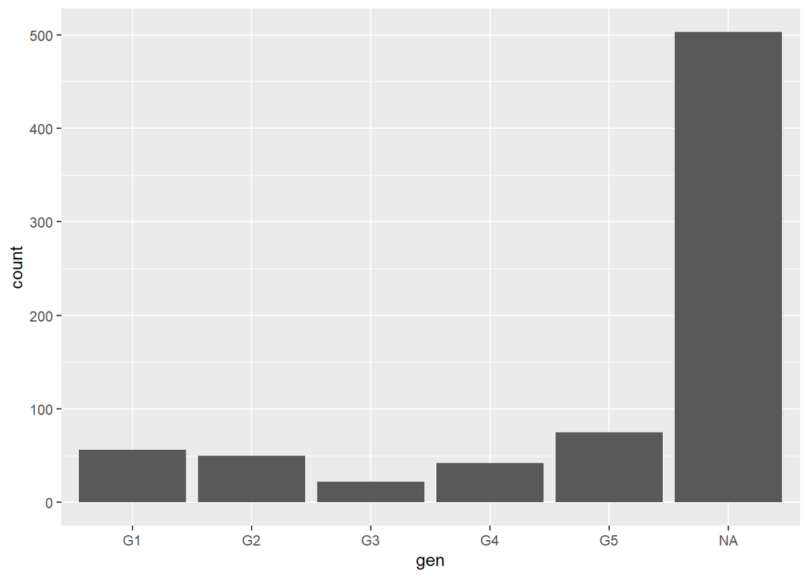

```r
boys %>% ggplot(aes(x=gen))+geom_bar()
```

##Assessing missing data

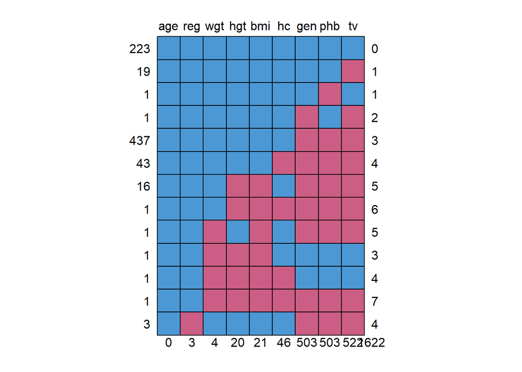

```
##     age reg wgt hgt bmi hc gen phb  tv
## 223   1   1   1   1   1  1   1   1   1    0
## 19    1   1   1   1   1  1   1   1   0    1
## 1     1   1   1   1   1  1   1   0   1    1
## 1     1   1   1   1   1  1   0   1   0    2
## 437   1   1   1   1   1  1   0   0   0    3
## 43    1   1   1   1   1  0   0   0   0    4
## 16    1   1   1   0   0  1   0   0   0    5
## 1     1   1   1   0   0  0   0   0   0    6
## 1     1   1   0   1   0  1   0   0   0    5
## 1     1   1   0   0   0  1   1   1   1    3
## 1     1   1   0   0   0  0   1   1   1    4
## 1     1   1   0   0   0  0   0   0   0    7
## 3     1   0   1   1   1  1   0   0   0    4
##       0   3   4  20  21 46 503 503 522 1622
```

```r
md.pattern(boys)
```

3. Create a missingness indicator for the variables gen, phb and tv.

```r
boys_mising <- boys %>%
  mutate(gen_mis = is.na(gen),
         phb_mis = is.na(phb),
         tv_mis  = is.na(tv))
```

4. Assess whether missingness in the variables gen, phb and tv is related to someones age

```r
boys_mising %>% group_by(gen_mis) %>% summarise(mean(age))
```

```
## # A tibble: 2 × 2
##   gen_mis `mean(age)`
##   <lgl>         <dbl>
## 1 FALSE         14.0
## 2 TRUE           6.79
```

```r
boys_mising %>% group_by(phb_mis) %>% summarise(mean(age))
```

```
## # A tibble: 2 × 2
##   phb_mis `mean(age)`
##   <lgl>         <dbl>
## 1 FALSE         14.0
## 2 TRUE           6.79
```

```r
boys_mising %>% group_by(tv_mis) %>% summarise(mean(age))
```

```
## # A tibble: 2 × 2
##   tv_mis `mean(age)`
##   <lgl>        <dbl>
## 1 FALSE        14.1
## 2 TRUE          7.02
```

5. Create a histogram for the variable age, faceted by whether or not someone has a missing value on gen.

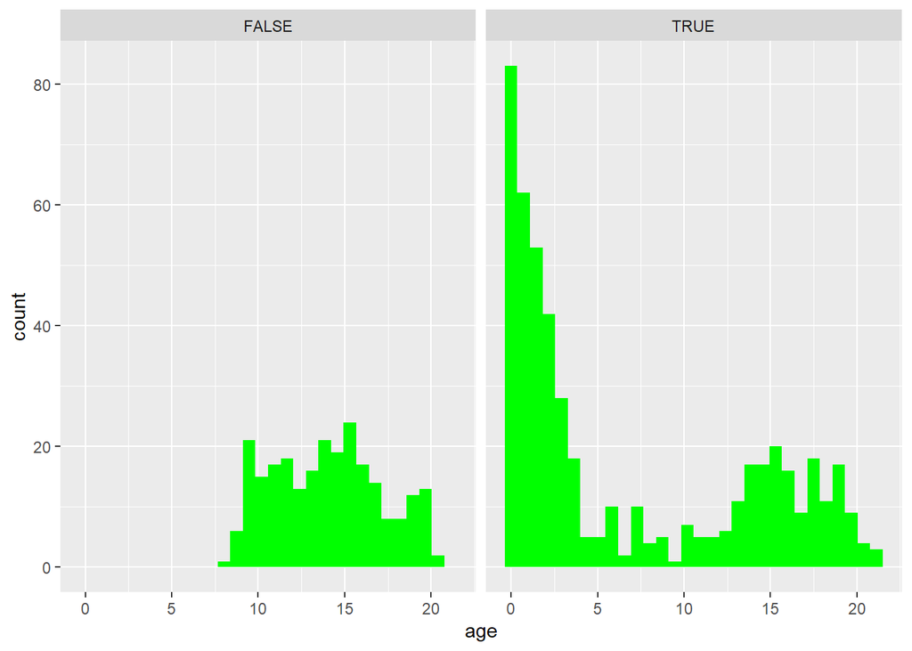

```r
boys_mising %>%ggplot(aes(x=age))+geom_histogram(fill="green")+facet_wrap(~gen_mis)
```

6. Create a scatterplot with age on the x-axis and bmi on the y-axis, using the function geom_point().

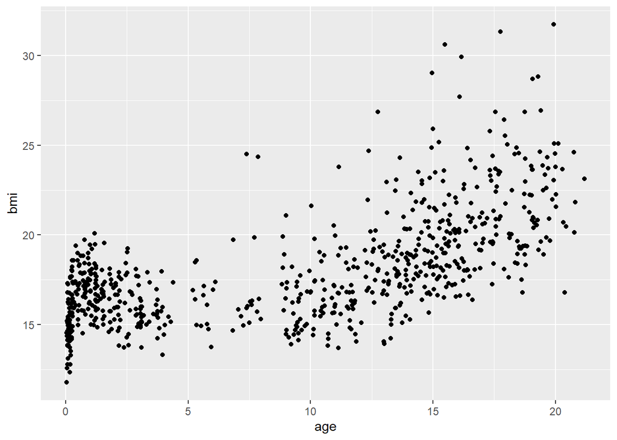

```r
boys_mising%>%ggplot(aes(x=age, y=bmi))+geom_point()
```

7. Add a colour aesthetic to the previous plot using the missingness indicator of the variable gen.

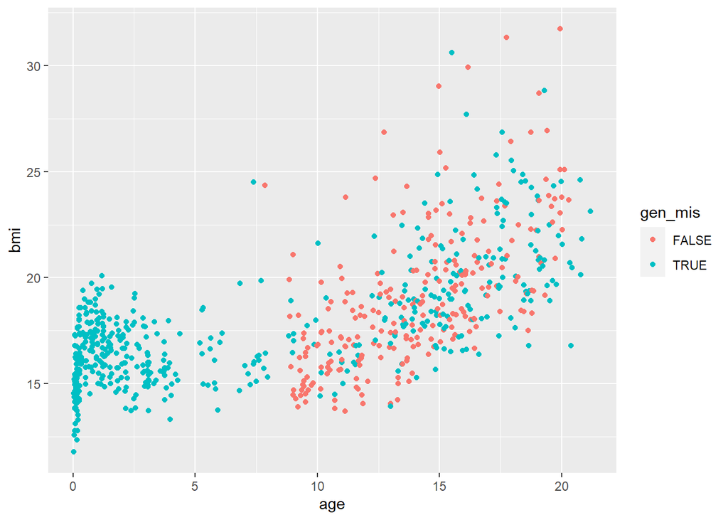

```r
boys_mising%>%ggplot(aes(x=age, y=bmi))+geom_point(aes(colour=gen_mis))
```

##Visualizing the boys data 8. Visualize the relationship between reg (region) and age using a boxplot.

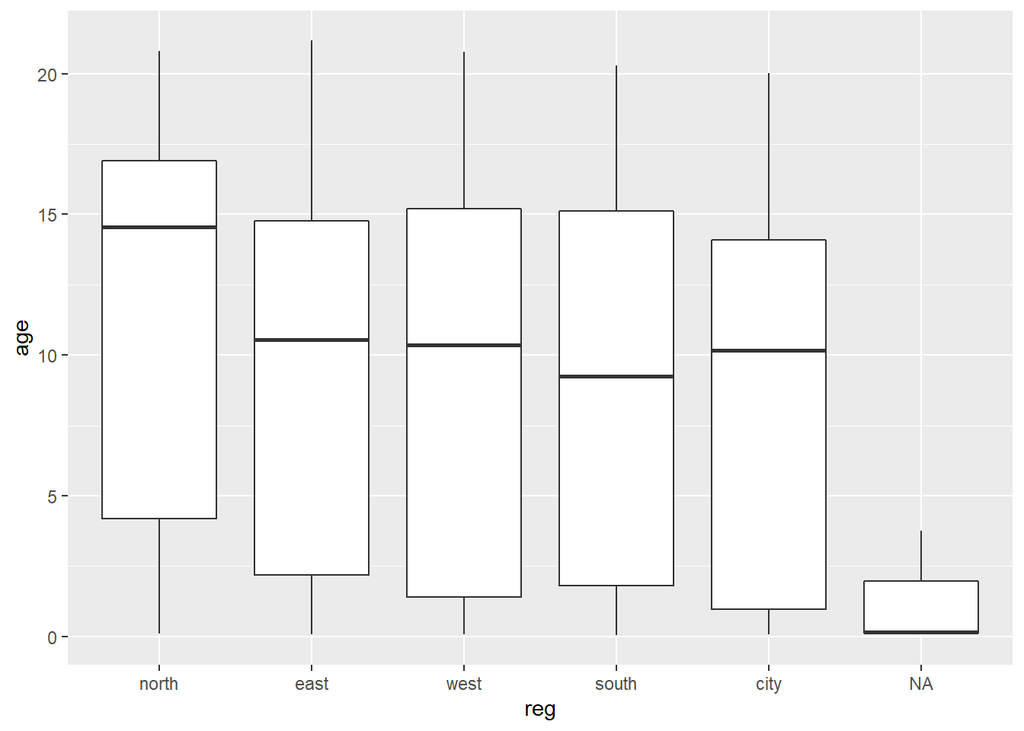

```r
boys_mising%>%ggplot(aes(x=reg, y=age))+geom_boxplot()
```

9. Create a density plot of age, splitting the densities by gen using the fill aesthetic.

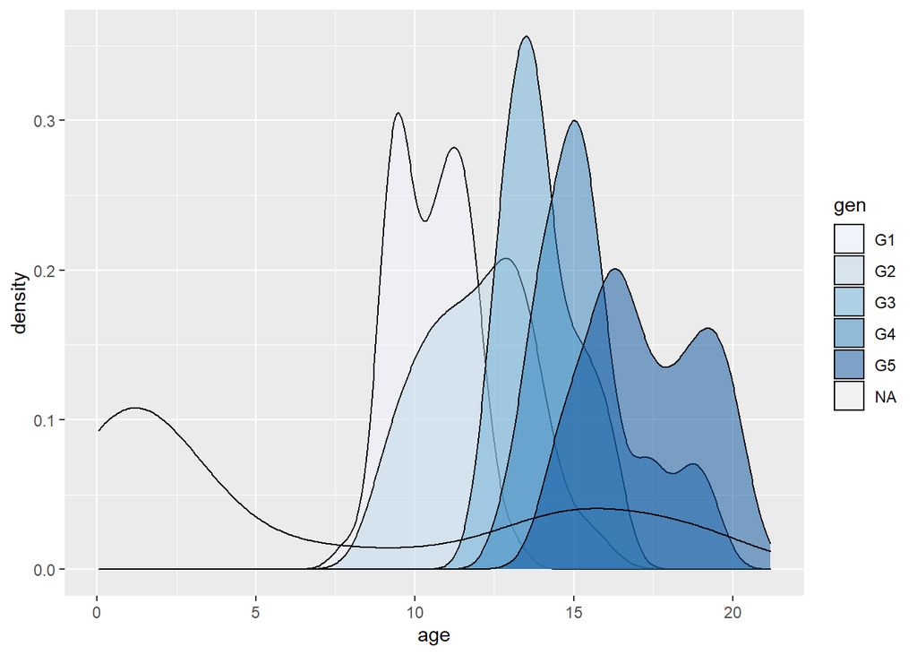

```r
boys_mising%>%ggplot(aes(x=age))+geom_density(aes(fill=gen), alpha=0.5)+scale_fill_brewer()
```

10. Create a diverging bar chart for hgt in the boys data set, that displays for every age year that year’s mean height in deviations from the overall average hgt.

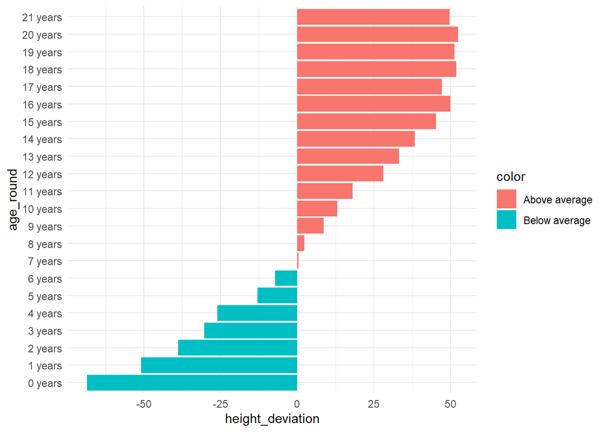

```r
boys %>% mutate(age_round=cut(age, 0:22, labels = paste0(0:21, " years")),
         height_deviation = hgt - mean(hgt, na.rm = TRUE)) %>% group_by(age_round) %>% summarize(height_deviation = mean(height_deviation, na.rm = TRUE)) %>%
  mutate(color = ifelse(height_deviation > 0, "Above average", "Below average")) %>%
  ggplot(aes(x = height_deviation, y = age_round, fill = color)) +
  geom_bar(stat = "identity") +
  theme_minimal()
```

##Regression visualization 11. Load the data elastic1 and elastic2 and bind the data frames together using the function bind_rows() and add a grouping variable indicating whether an observation comes from elastic1 or from elastic2.

```r
elastic <- bind_rows("Elastic1" = elastic1,
                     "Elastic2" = elastic2,
                     .id = "Set")
```

12. Create a scatterplot mapping stretch on the x-axis and distance on the y-axis, and map the just created group indicator as the color aesthetic.

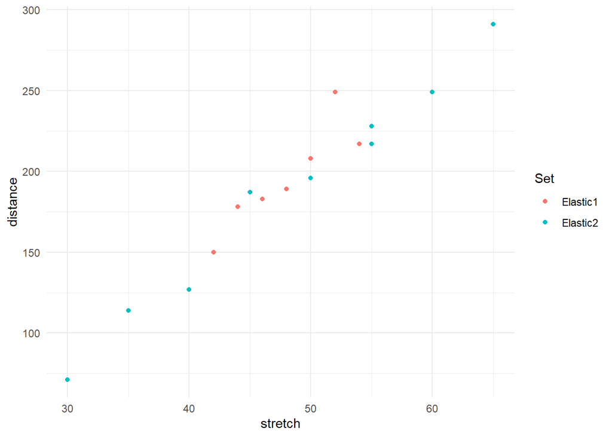

```r
elastic %>% ggplot(aes(x=stretch, y=distance, colour=Set))+geom_point()+theme_minimal()
```

13. Recreate the previous plot, but now assess whether the results of the two data sets appear consistent by adding a linear regression line.

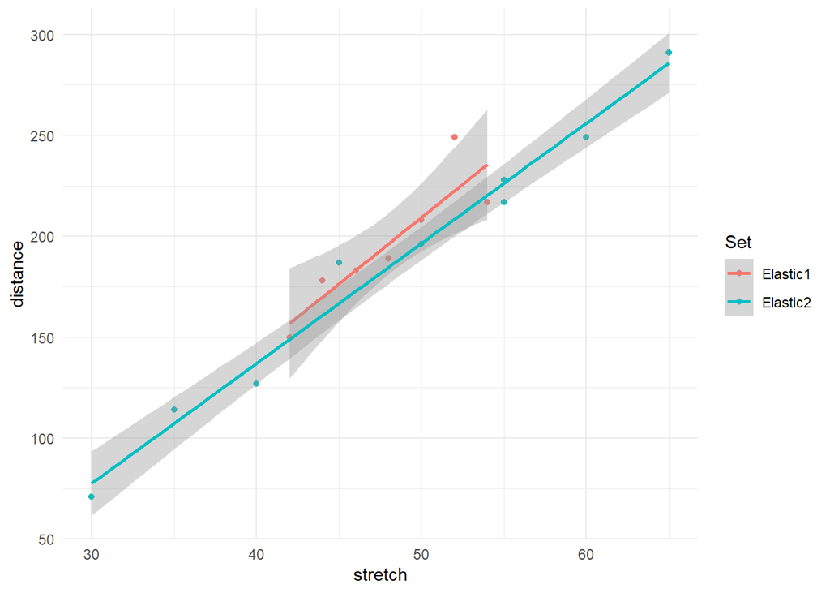

```r
elastic %>% ggplot(aes(x=stretch, y=distance, colour=Set))+geom_point()+geom_smooth(method = "lm")+theme_minimal()
```

14. For each of the data sets elastic1 and elastic2, fit a regression model with y = distance on x = stretch using lm(y ~ x, data).

```r
fit1<-lm(distance ~ stretch, elastic1)
fit2<-lm(distance ~ stretch, elastic2)
```

15. For both of the previously created fitted models, determine the fitted values and the standard errors of the fitted values, and the proportion explained variance R2.

```r
predict(fit1, se.fit = TRUE)
```

```
## $fit
##        1        2        3        4        5        6        7
## 183.1429 235.7143 196.2857 209.4286 170.0000 156.8571 222.5714
##
## $se.fit
## [1]  6.586938 10.621119  5.891537  6.586938  8.331891 10.621119  8.331891
##
## $df
## [1] 5
##
## $residual.scale
## [1] 15.58754
```

```r
predict(fit2, se.fit = TRUE)
```

```
## $fit
##         1         2         3         4         5         6         7         8
##  77.58333 196.58333 137.08333 166.83333 256.08333 226.33333 107.33333 226.33333
##         9
## 285.83333
##
## $se.fit
## [1] 6.740293 3.520003 4.358744 3.635444 5.060323 4.064550 5.453165 4.064550
## [9] 6.296773
##
## $df
## [1] 7
##
## $residual.scale
## [1] 10.44202
```

```r
fit1 %>% summary()
```

```
##
## Call:
## lm(formula = distance ~ stretch, data = elastic1)
##
## Residuals:
##        1        2        3        4        5        6        7
##  -0.1429 -18.7143  -7.2857  -1.4286   8.0000  -6.8571  26.4286
##
## Coefficients:
##             Estimate Std. Error t value Pr(>|t|)
## (Intercept) -119.143     70.943  -1.679  0.15391
## stretch        6.571      1.473   4.462  0.00663 **
## ---
## Signif. codes:  0 '***' 0.001 '**' 0.01 '*' 0.05 '.' 0.1 ' ' 1
##
## Residual standard error: 15.59 on 5 degrees of freedom
## Multiple R-squared:  0.7992, Adjusted R-squared:  0.7591
## F-statistic: 19.91 on 1 and 5 DF,  p-value: 0.006631
```

```r
fit2 %>% summary()
```

```
##
## Call:
## lm(formula = distance ~ stretch, data = elastic2)
##
## Residuals:
##      Min       1Q   Median       3Q      Max
## -10.0833  -7.0833  -0.5833   5.1667  20.1667
##
## Coefficients:
##              Estimate Std. Error t value Pr(>|t|)
## (Intercept) -100.9167    15.6102  -6.465 0.000345 ***
## stretch        5.9500     0.3148  18.899 2.89e-07 ***
## ---
## Signif. codes:  0 '***' 0.001 '**' 0.01 '*' 0.05 '.' 0.1 ' ' 1
##
## Residual standard error: 10.44 on 7 degrees of freedom
## Multiple R-squared:  0.9808, Adjusted R-squared:  0.978
## F-statistic: 357.2 on 1 and 7 DF,  p-value: 2.888e-07
```

16. Study the residual versus leverage plots for both models

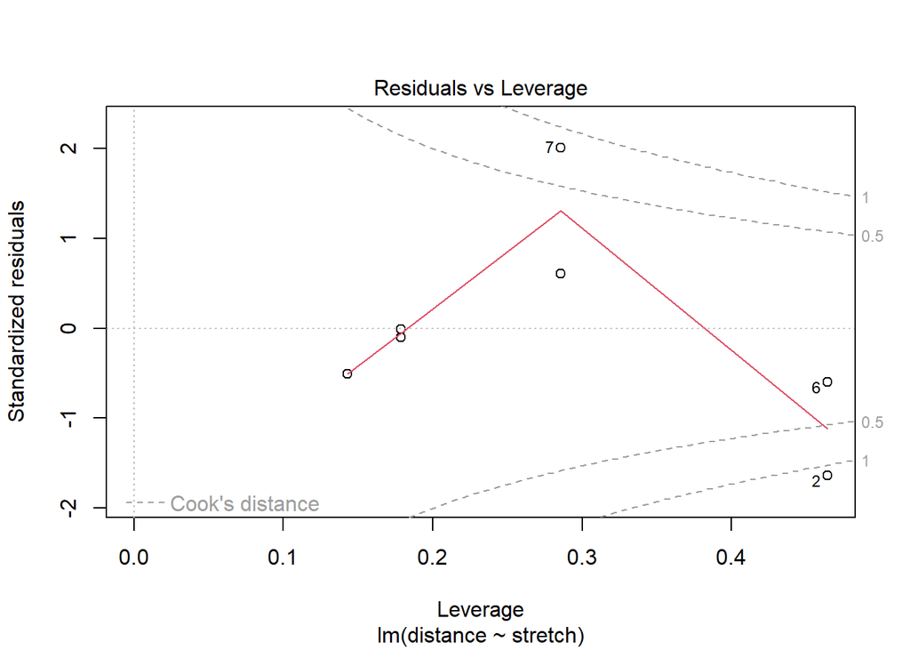

```r
fit1 %>% plot(which = 5)
```

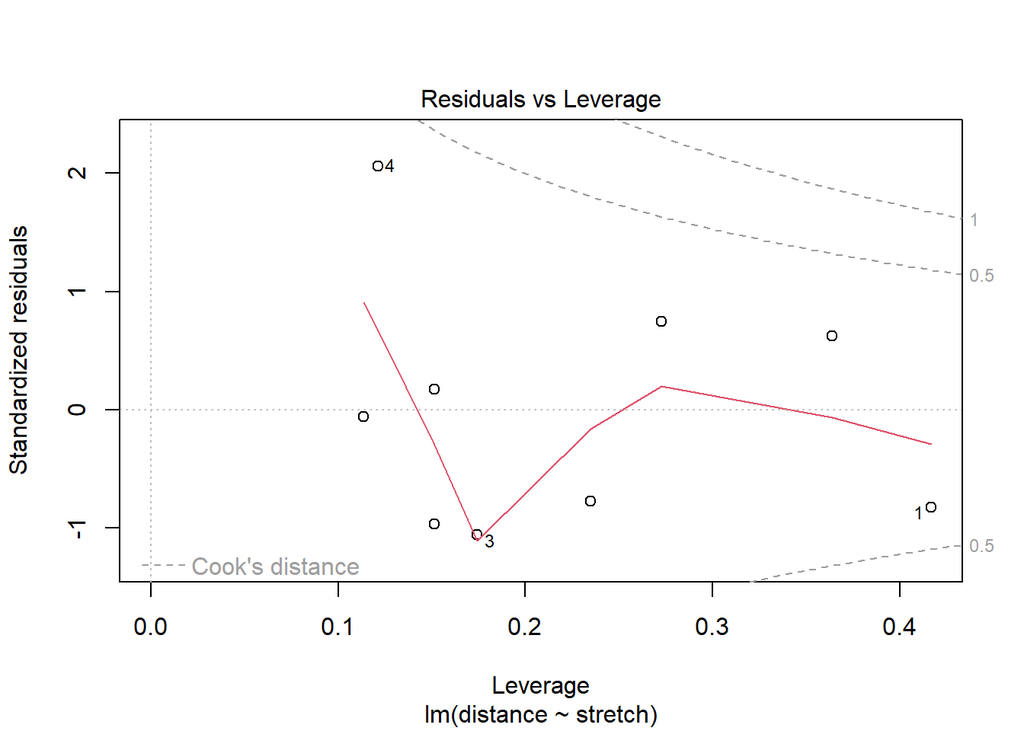

```r
fit2 %>% plot(which = 5)
```

17. Use the elastic2 variable stretch to obtain predictions on the model fitted on elastic1.

```r
prediction1 <- predict(fit1, newdata = elastic2)
```

18. Now make a scatterplot to investigate similarity between the predicted values and the observed values for elastic2.

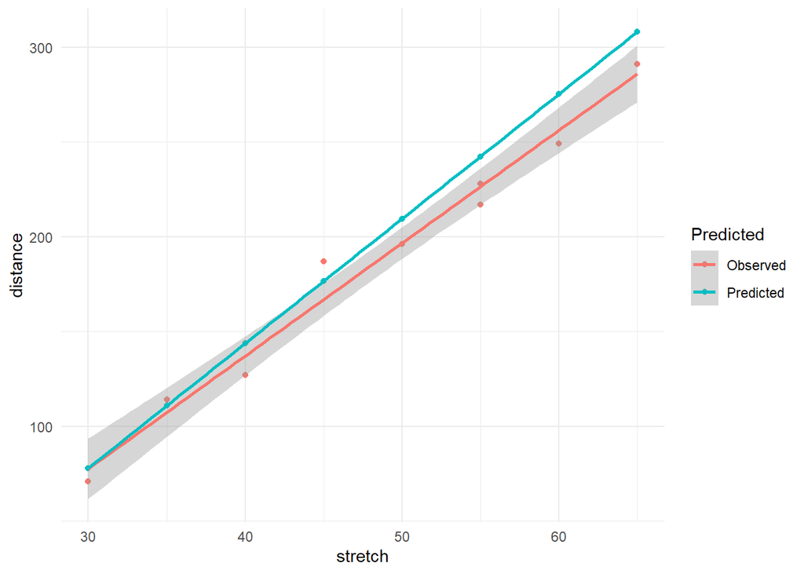

```r
prediction_dat <-
  data.frame(distance = prediction1,
             stretch  = elastic2$stretch) %>%
  bind_rows(Predicted = .,
            Observed  = elastic2,
            .id = "Predicted")

prediction_dat %>%
  ggplot(aes(stretch, distance, col = Predicted)) +
  geom_point() +
  geom_smooth(method = "lm") +
  theme_minimal()
```